# Practical 4 - Physiological Sensors

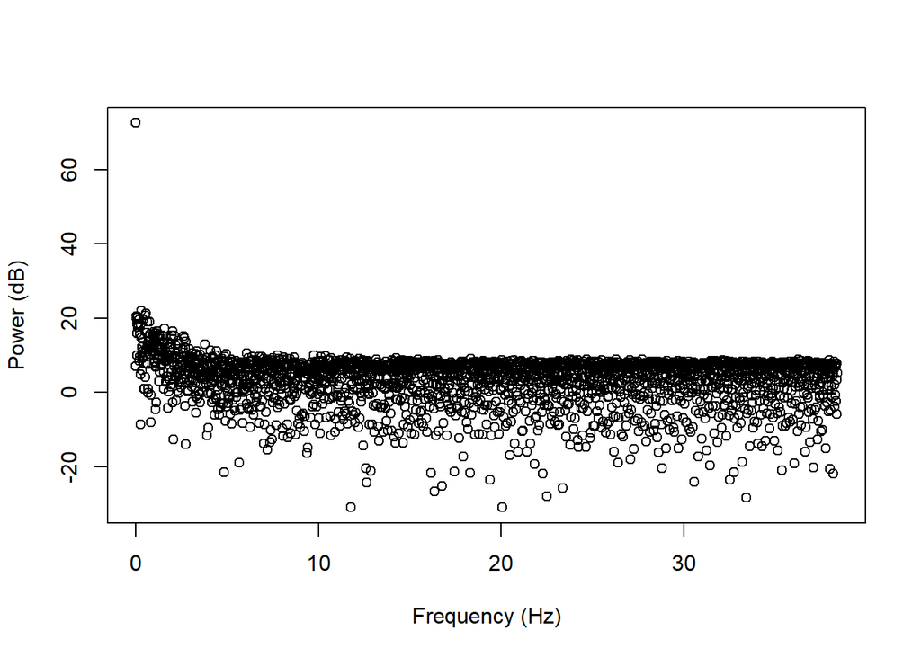

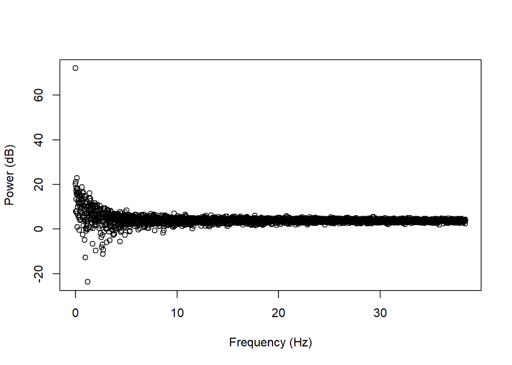

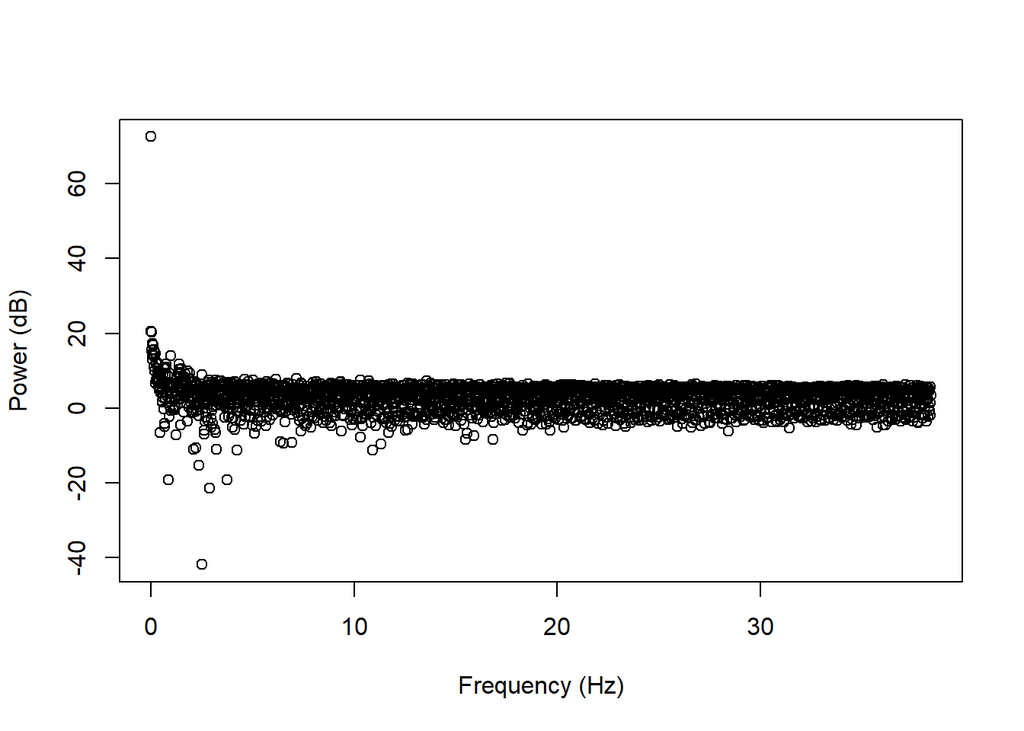

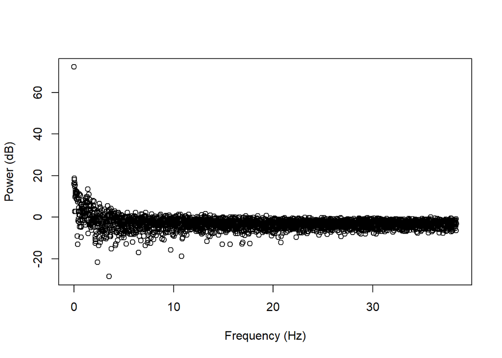

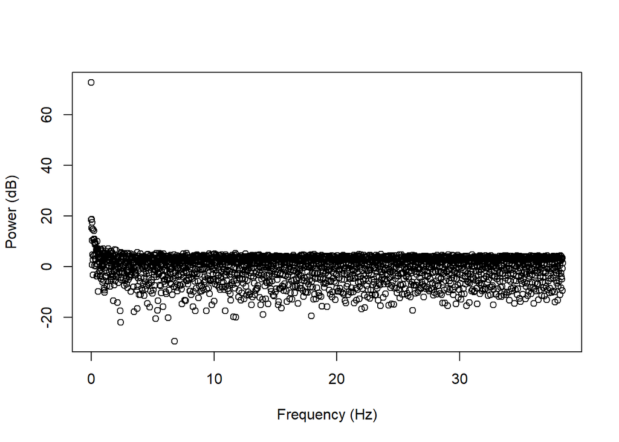

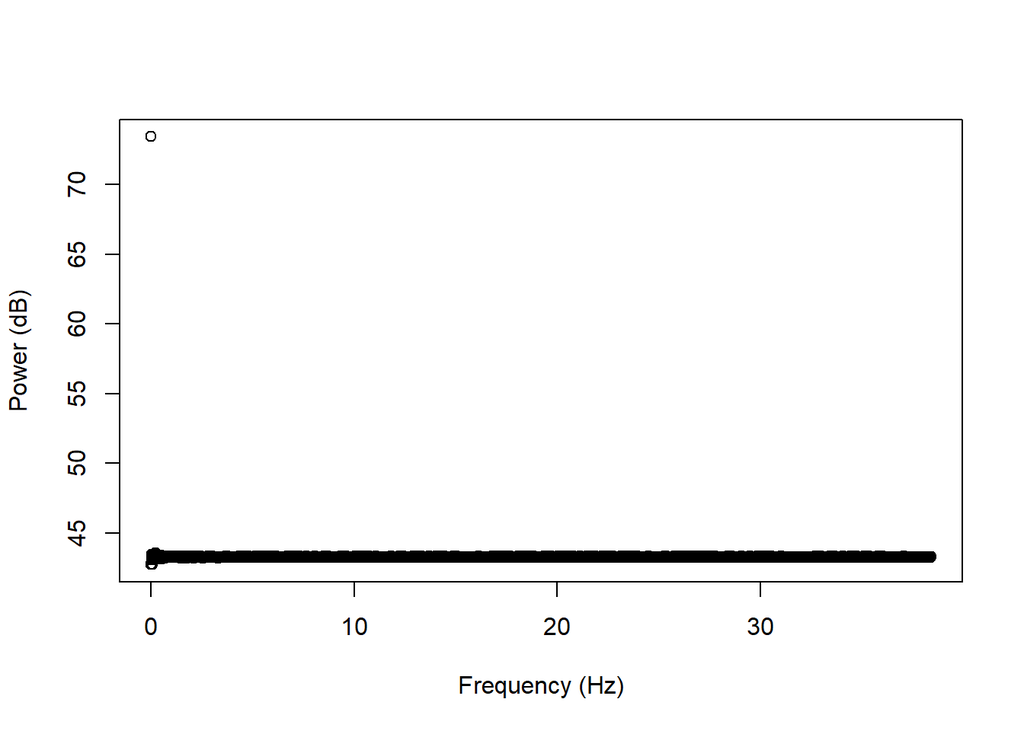

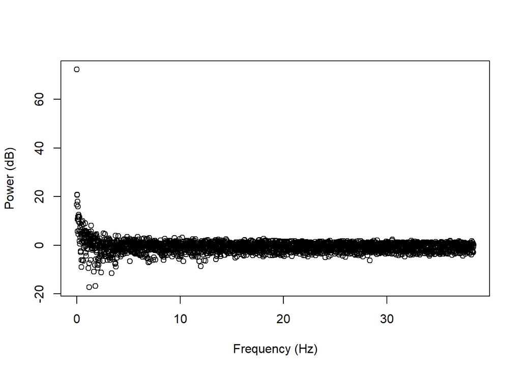

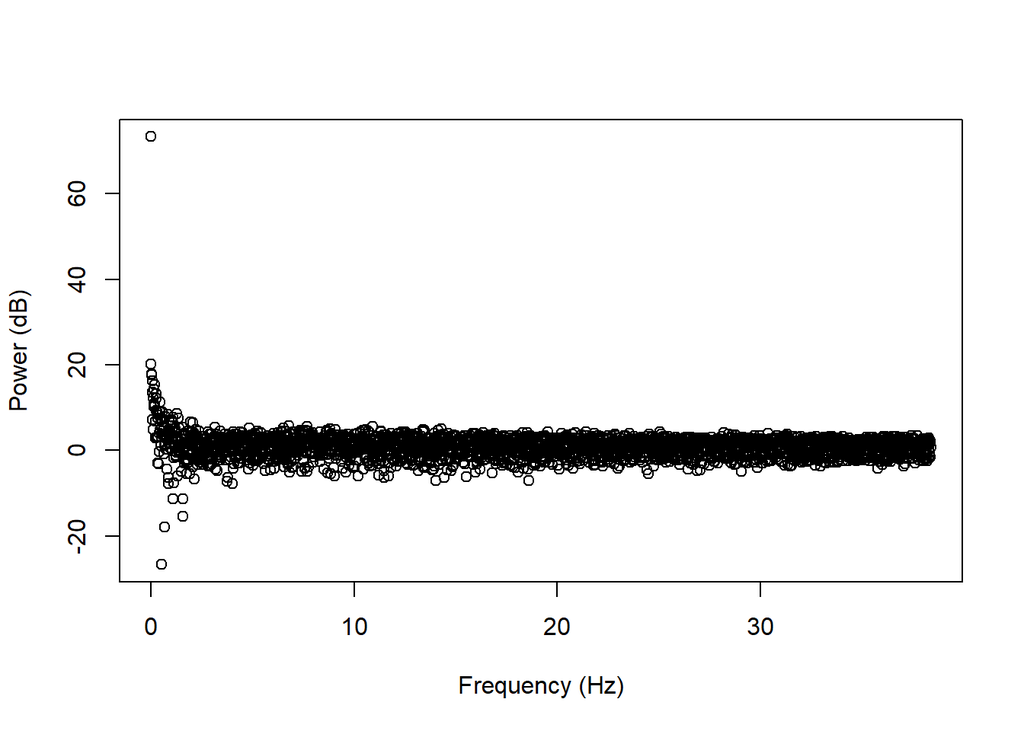

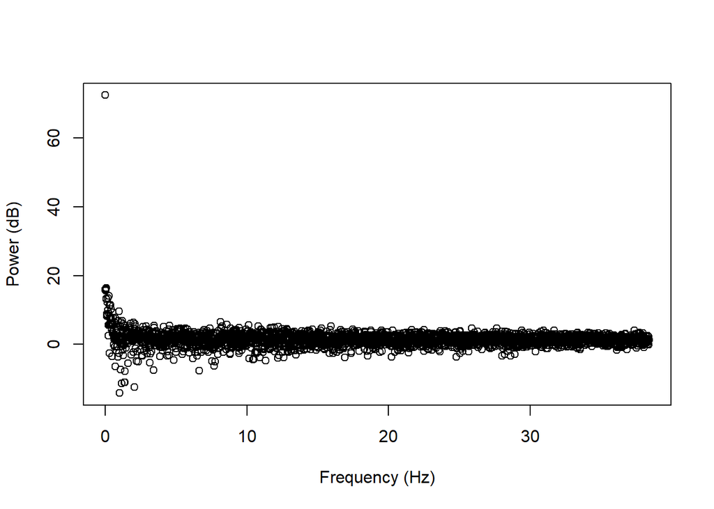

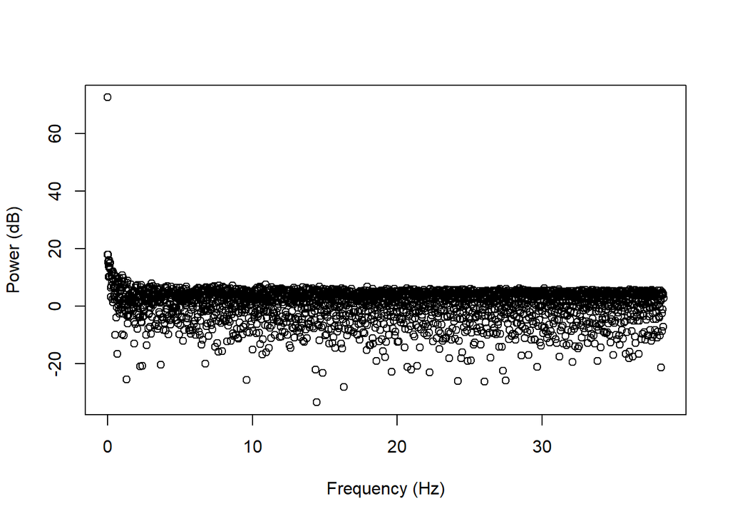

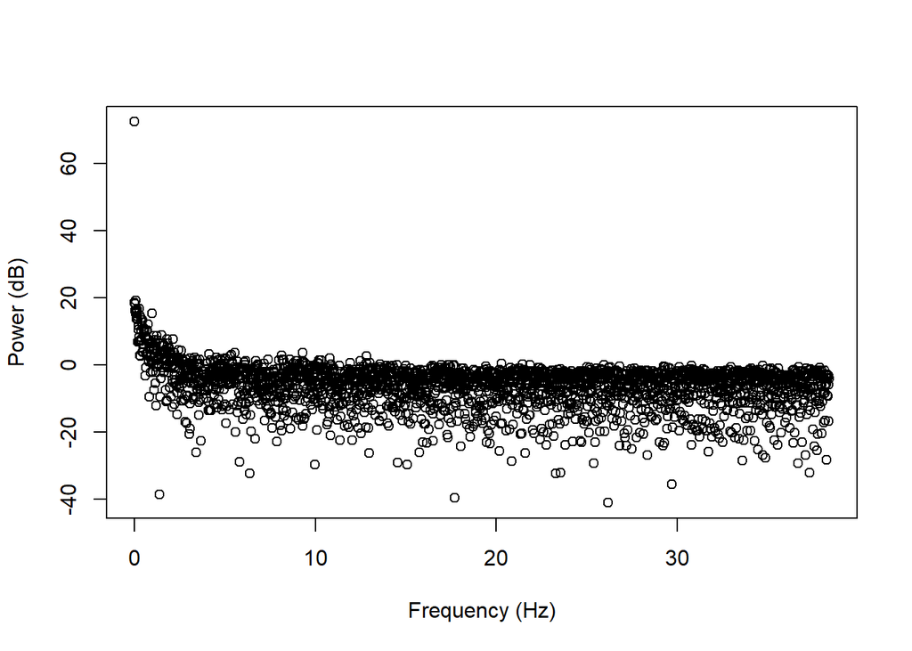

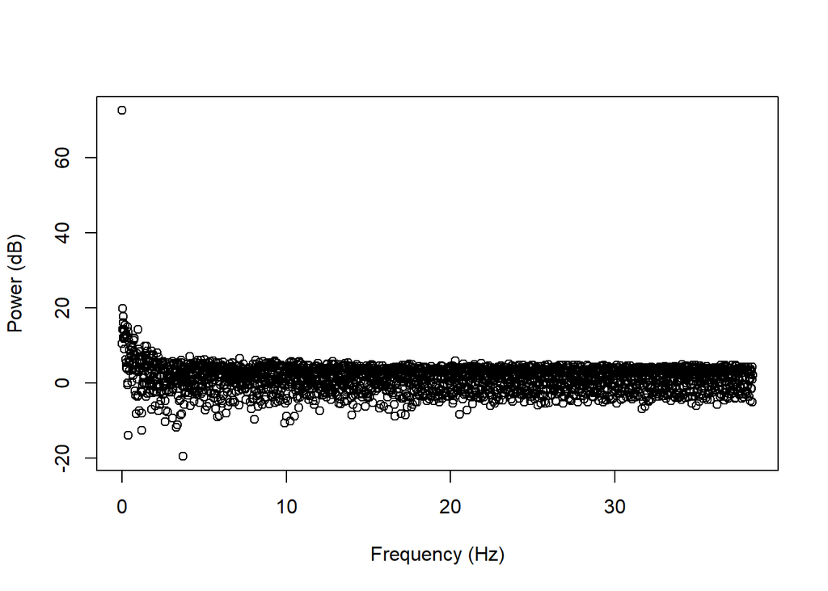

[2 more figures not shown]

```r
##Code for Eyes Opened looking at each channel individually on a plot
# Load required libraries
library(eegkit)
library(dplyr)
library(ggplot2)
library(gridExtra)

# Assuming eeg_train is already loaded
# Calculate sampling rate Fs (samples per second)
num_samples <- nrow(eeg_train)
total_duration <- 117  # seconds
Fs <- num_samples / total_duration

# Function to plot EEG PSD with ggplot2 for each channel
plot_eeg_psd_individual <- function(eeg_data, Fs) {
  num_channels <- ncol(eeg_data)
  plots <- list()

  for (ch in 1:num_channels) {
    # Extract EEG data for the current channel
    eeg_channel <- eeg_data[, ch]

    # Calculate the power spectral density
    psd_result <- eegkit::eegpsd(eeg_channel, Fs = Fs)

    # Create a data frame from the psd_result
    psd_data <- data.frame(
      Frequency = psd_result$freq,
      Power = psd_result$spec
    )

    # Generate the plot using ggplot2
    p <- ggplot(psd_data, aes(x = Frequency, y = Power)) +
      geom_line() +
      labs(
        x = "Frequency (Hz)",
        y = "Power"
      ) +
      ggtitle(paste("Eyes Open - Channel", ch)) +  # Title for eyes open and channel
      theme_minimal() +
      theme(plot.title = element_text(hjust = 0.5, size = 10))  # Center and resize the title

    plots[[ch]] <- p
  }

  return(plots)
}

# Filter data for eyes open
eeg_open <- eeg_train %>% filter(eyeDetection == 0) %>% select(-eyeDetection, -ds)

# Plot EEG Power Spectral Density (PSD) for each channel separately for eyes open
psd_open_plots <- plot_eeg_psd_individual(eeg_open, Fs)
```

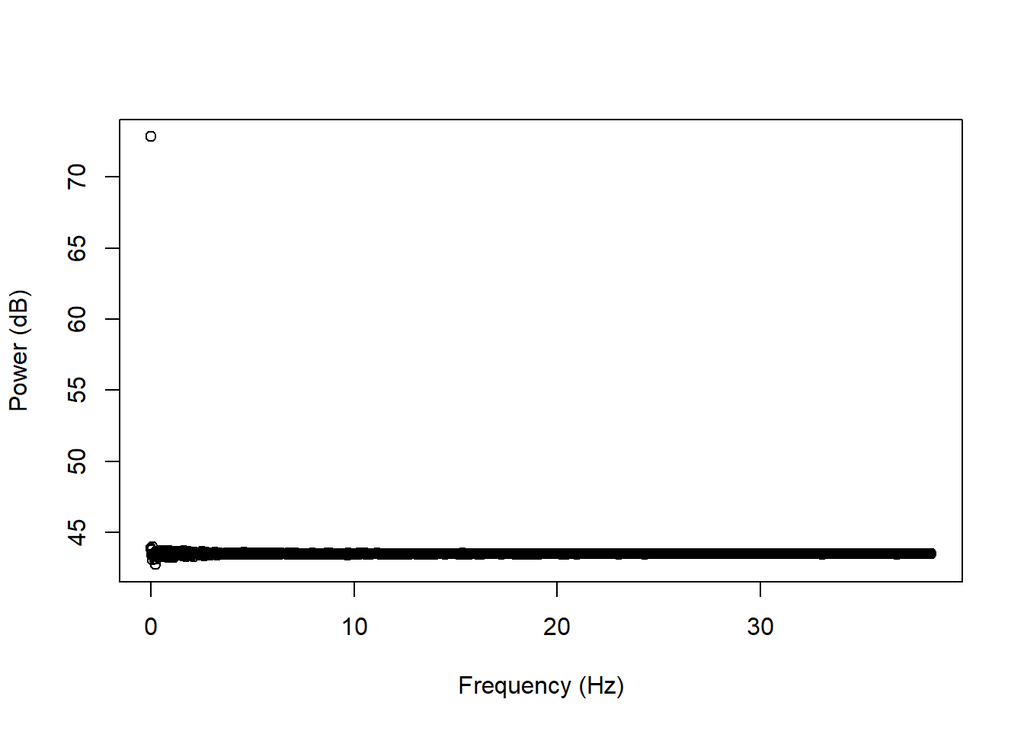

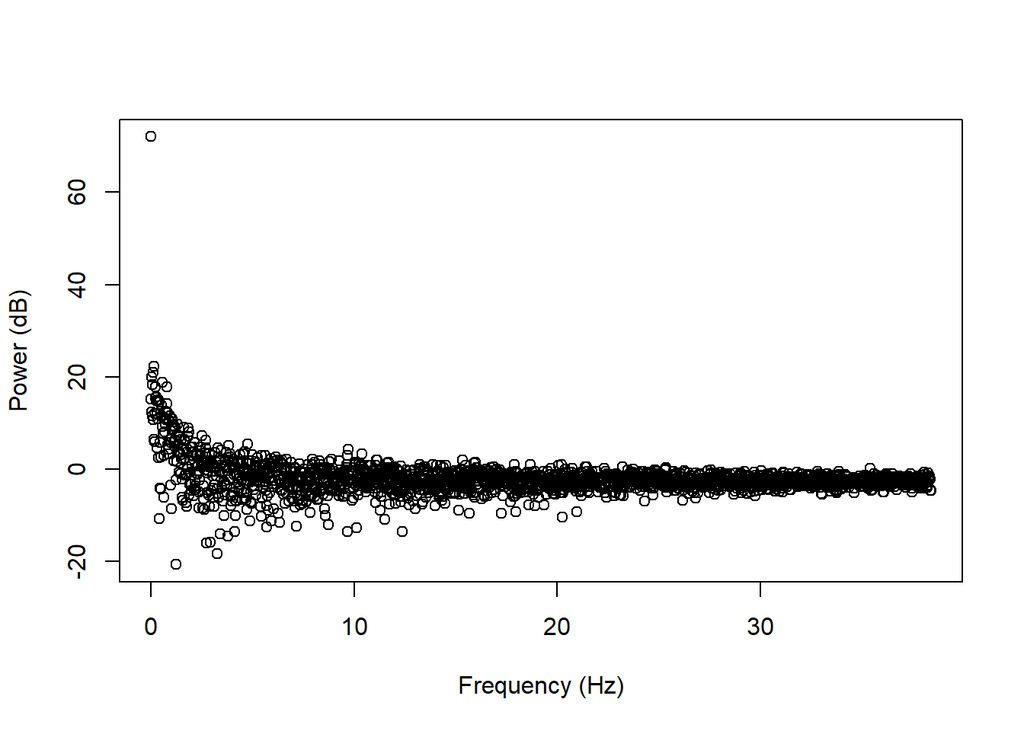

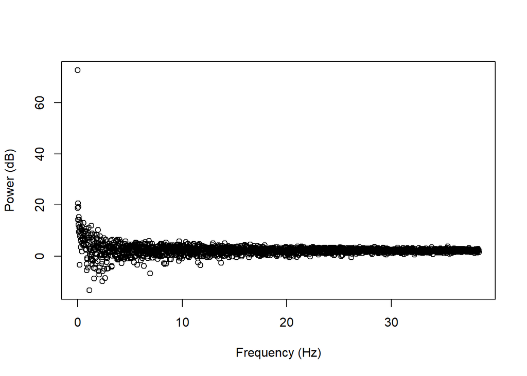

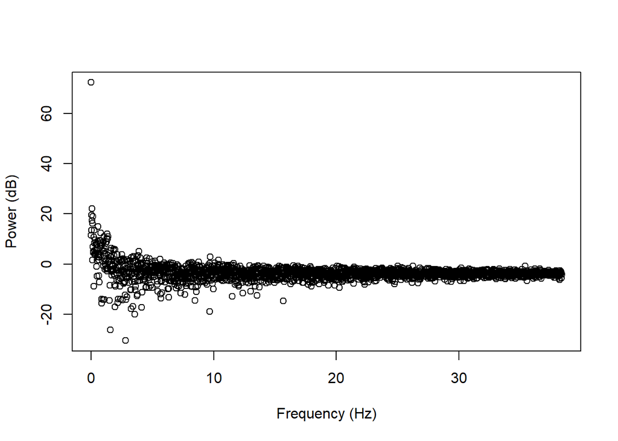

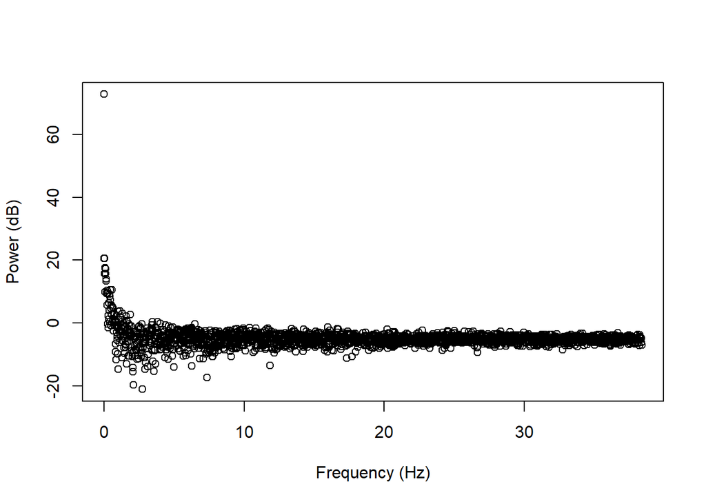

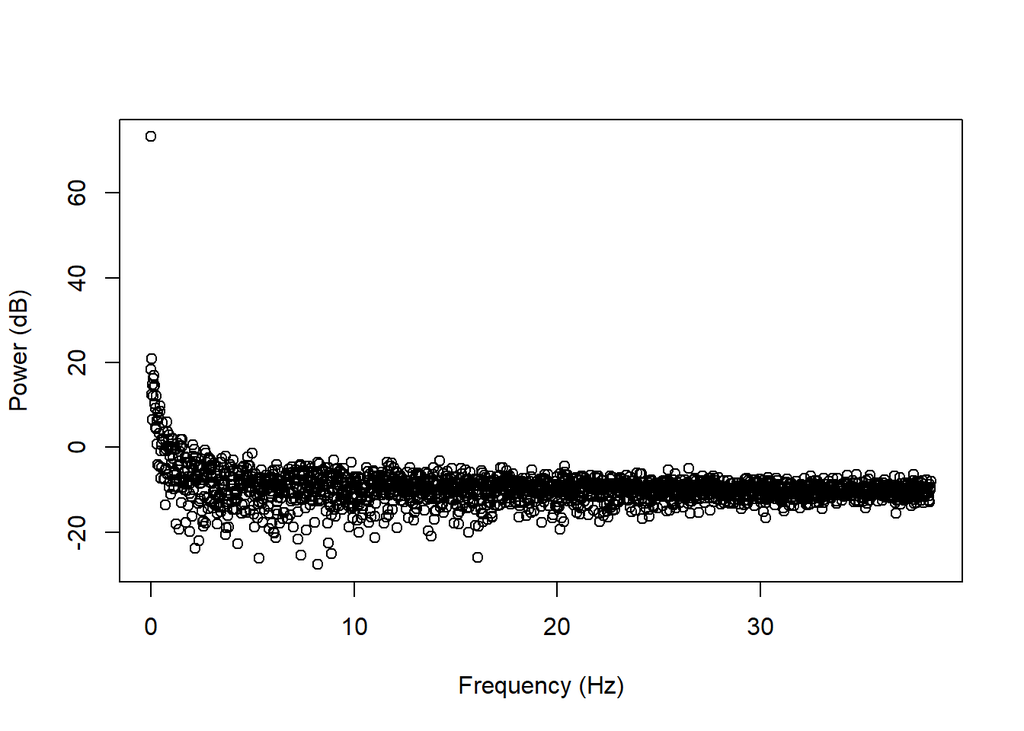

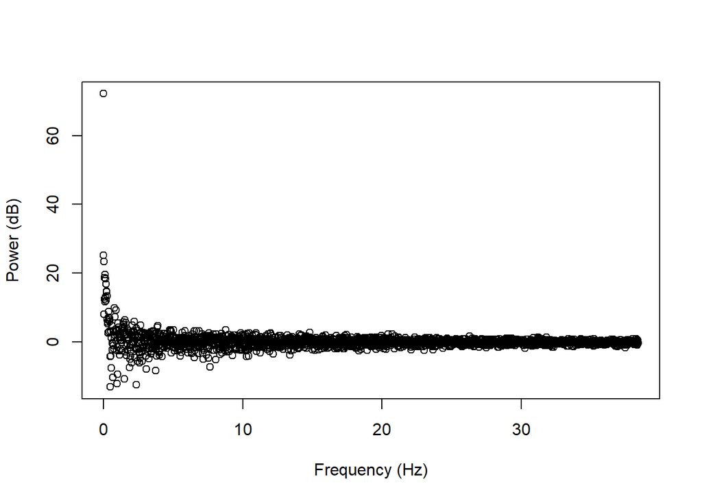

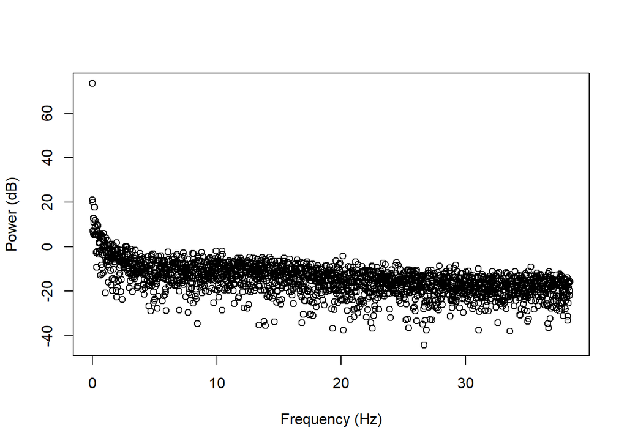

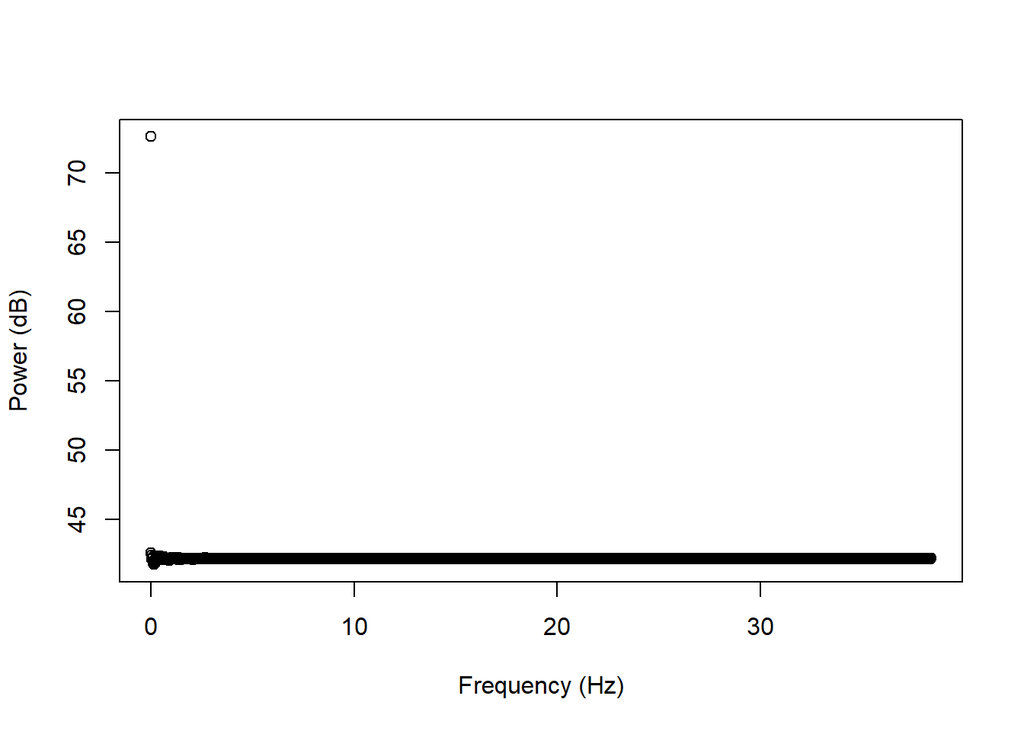

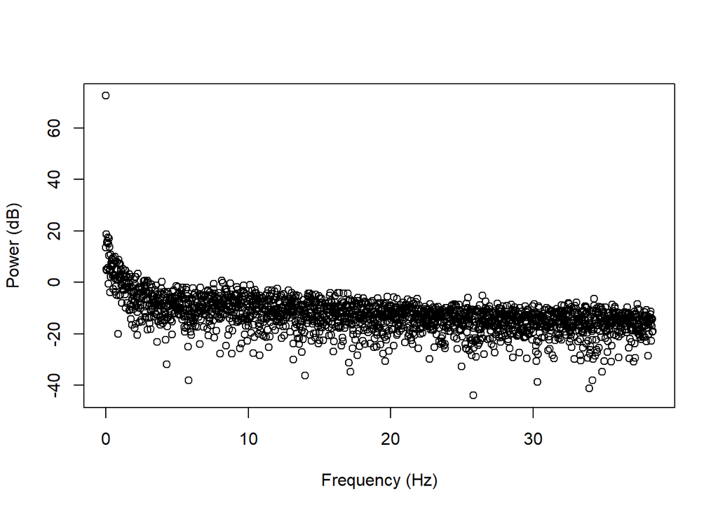

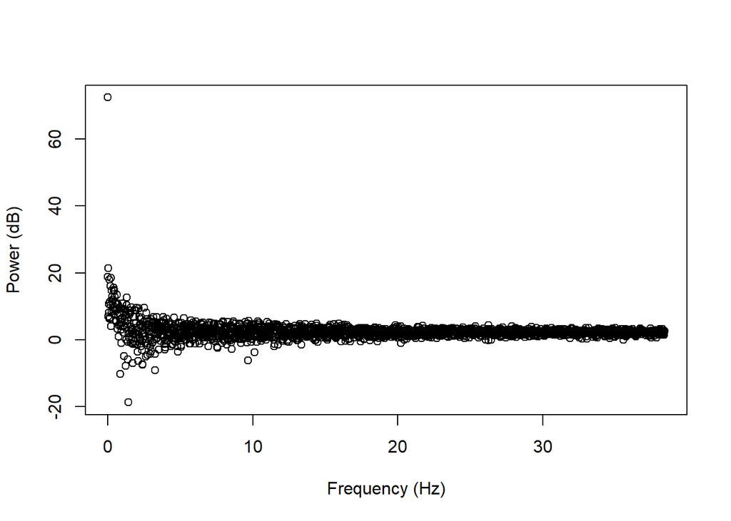

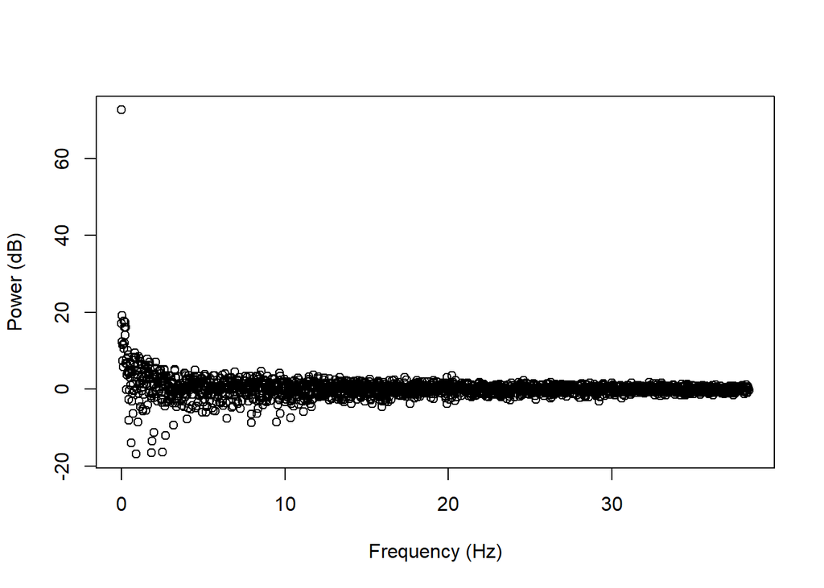

[2 more figures not shown]

```r
##Code for Eyes Closed looking at each channel individually on a plot
# Load required libraries
library(eegkit)
library(dplyr)
library(ggplot2)
library(gridExtra)

# Assuming eeg_train is already loaded
# Calculate sampling rate Fs (samples per second)
num_samples <- nrow(eeg_train)
total_duration <- 117  # seconds
Fs <- num_samples / total_duration

# Function to plot EEG PSD with ggplot2 for each channel
plot_eeg_psd_individual <- function(eeg_data, Fs) {
  num_channels <- ncol(eeg_data)
  plots <- list()

  for (ch in 1:num_channels) {
    # Extract EEG data for the current channel
    eeg_channel <- eeg_data[, ch]

    # Calculate the power spectral density
    psd_result <- eegkit::eegpsd(eeg_channel, Fs = Fs)

    # Create a data frame from the psd_result
    psd_data <- data.frame(
      Frequency = psd_result$freq,
      Power = psd_result$spec
    )

    # Generate the plot using ggplot2
    p <- ggplot(psd_data, aes(x = Frequency, y = Power)) +
      geom_line() +
      labs(
        x = "Frequency (Hz)",
        y = "Power"
      ) +
      ggtitle(paste("Eyes Closed - Channel", ch)) +  # Title for eyes closed and channel
      theme_minimal() +
      theme(plot.title = element_text(hjust = 0.5, size = 10))  # Center and resize the title

    plots[[ch]] <- p
  }

  return(plots)
}

# Filter data for eyes closed
eeg_closed <- eeg_train %>% filter(eyeDetection == 1) %>% select(-eyeDetection, -ds)

# Plot EEG Power Spectral Density (PSD) for each channel separately for eyes closed
psd_closed_plots <- plot_eeg_psd_individual(eeg_closed, Fs)
```

#### Independent Component Analysis

We may also wish to explore whether there are multiple sources of neuronal activity being picked up by the sensors.  
This can be achieved using a process known as independent component analysis (ICA) which decorrelates the channels and identifies the primary sources of signal within the decorrelated matrix.

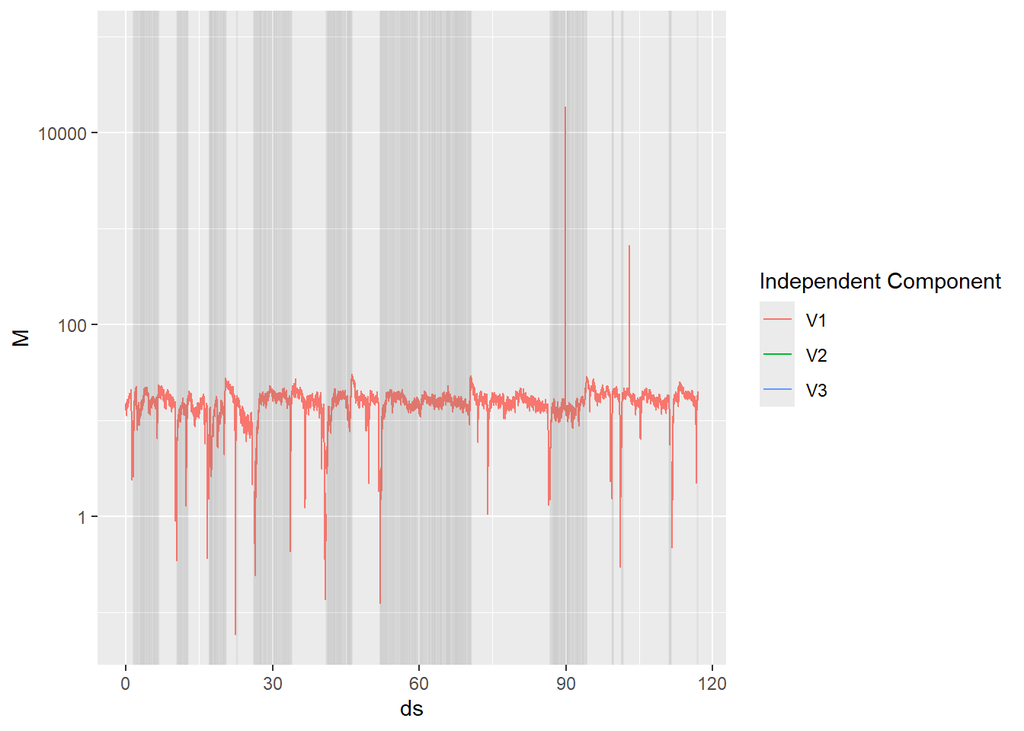

```r
ica <- eegkit::eegica(eeg_train %>% dplyr::select(-eyeDetection, -ds), nc=3, method='fast', type='time')
mix <- dplyr::as_tibble(ica$M)
mix$eyeDetection <- eeg_train$eyeDetection
mix$ds <- eeg_train$ds

mix_melt <- reshape2::melt(mix, id.vars=c("eyeDetection", "ds"), variable.name = "Independent Component", value.name = "M")


ggplot2::ggplot(mix_melt, ggplot2::aes(x=ds, y=M, color=`Independent Component`)) +
  ggplot2::geom_line() +
  ggplot2::geom_vline(ggplot2::aes(xintercept=ds), data=dplyr::filter(mix_melt, eyeDetection==1), alpha=0.005) +
  ggplot2::scale_y_log10()
```

**9** Does this suggest eye opening relates to an independent component of activity across the electrodes?

The V1 independent component (i.e., red line) shows significant and frequent drops that seem to coincide, for the most part, with the dark grey vertical lines. In other words, in most cases in the plot, a dark grey vertical line (i.e., when the eyes close) seems to appear right after a significant drop in the V1 independent component variable. This tells us that there are significant drops in activity whenever the eyes are about to close, which could indicate that V1 is strongly related to eye closure activity. Thus, the activity of eye opening (when eyeDetection=0) relates inversely to the V1 independent component variable. When the eyes open, the independent component, V1, tends to show somewhat potentially higher activity levels compared to when the eyes are closed.

Therefore, we show that eye closing and eye opening may significantly affect the V1 independent component variable’s activity across the electrodes. However, the other independent component variables (i.e., V2 and V3) are not really visible at all in the plot above, which suggests that their contributions could be negligible or even may be zero.

### Eye Opening Prediction

Now that we’ve explored the data let’s use a simple model to see how well we can predict eye status from the EEGs:

```r
# Convert the training and validation datasets to matrices
eeg_train_matrix <- as.matrix(dplyr::select(eeg_train, -eyeDetection, -ds))
eeg_train_labels <- as.numeric(eeg_train$eyeDetection) -1

eeg_validate_matrix <- as.matrix(dplyr::select(eeg_validate, -eyeDetection, -ds))
eeg_validate_labels <- as.numeric(eeg_validate$eyeDetection) -1

# Build the xgboost model
model <- xgboost(data = eeg_train_matrix,
                 label = eeg_train_labels,
                 nrounds = 100,
                 max_depth = 4,
                 eta = 0.1,
                 objective = "binary:logistic")
print(model)
```

```
## ##### xgb.Booster
## raw: 154.4 Kb
## call:
##   xgb.train(params = params, data = dtrain, nrounds = nrounds,
##     watchlist = watchlist, verbose = verbose, print_every_n = print_every_n,
##     early_stopping_rounds = early_stopping_rounds, maximize = maximize,
##     save_period = save_period, save_name = save_name, xgb_model = xgb_model,
##     callbacks = callbacks, max_depth = 4, eta = 0.1, objective = "binary:logistic")
## params (as set within xgb.train):
##   max_depth = "4", eta = "0.1", objective = "binary:logistic", validate_parameters = "TRUE"
## xgb.attributes:
##   niter
## callbacks:
##   cb.print.evaluation(period = print_every_n)
##   cb.evaluation.log()
## # of features: 14
## niter: 100
## nfeatures : 14
## evaluation_log:
##      iter train_logloss
##     <num>         <num>
##         1     0.6721733
##         2     0.6539652
## ---
##        99     0.3514004
##       100     0.3504083
```

```r
# Predict on the validation set
pred_prob <- predict(model, newdata = eeg_validate_matrix)

# Convert probabilities to class labels
pred_labels <- ifelse(pred_prob > 0.5, 1, 0)

# Ensure predictions and actual labels are factors with the same levels
pred_labels <- factor(pred_labels, levels = c(0, 1))
eeg_validate_labels <- factor(eeg_validate_labels, levels = c(0, 1))

# Evaluate the model
confusion_matrix <- caret::confusionMatrix(pred_labels, eeg_validate_labels)
print(confusion_matrix)
```

```
## Confusion Matrix and Statistics
##
##           Reference
## Prediction    0    1
##          0 1434  303
##          1  201 1058
##
##                Accuracy : 0.8318
##                  95% CI : (0.8179, 0.845)
##     No Information Rate : 0.5457
##     P-Value [Acc > NIR] : < 2.2e-16
##
##                   Kappa : 0.6586
##
##  Mcnemar's Test P-Value : 6.831e-06
##
##             Sensitivity : 0.8771
##             Specificity : 0.7774
##          Pos Pred Value : 0.8256
##          Neg Pred Value : 0.8403
##              Prevalence : 0.5457
##          Detection Rate : 0.4786
##    Detection Prevalence : 0.5798
##       Balanced Accuracy : 0.8272
##
##        'Positive' Class : 0
##
```

**10** Using the `caret` library (or any other library/model type you want such as a naive Bayes) fit another model to predict eye opening.

```r
##Naive Bayes Model
library(e1071)
library(caret)
library(dplyr)

# Prepare the training and validation datasets
eeg_train_matrix <- as.data.frame(dplyr::select(eeg_train, -eyeDetection, -ds))
eeg_train_labels <- as.factor(eeg_train$eyeDetection)

eeg_validate_matrix <- as.data.frame(dplyr::select(eeg_validate, -eyeDetection, -ds))
eeg_validate_labels <- as.factor(eeg_validate$eyeDetection)

# Build the Naive Bayes model
nb_model <- naiveBayes(x = eeg_train_matrix, y = eeg_train_labels)

# Make predictions on the validation set
nb_predictions <- predict(nb_model, eeg_validate_matrix)

# Ensure predictions and actual labels are factors with the same levels
nb_predictions <- factor(nb_predictions, levels = levels(eeg_validate_labels))

# Calculate confusion matrix
confusion_matrix <- confusionMatrix(nb_predictions, eeg_validate_labels)

# Print the confusion matrix
print(confusion_matrix)
```

```
## Confusion Matrix and Statistics
##
##           Reference
## Prediction    0    1
##          0  327  254
##          1 1308 1107
##
##                Accuracy : 0.4786
##                  95% CI : (0.4606, 0.4967)
##     No Information Rate : 0.5457
##     P-Value [Acc > NIR] : 1
##
##                   Kappa : 0.0126
##
##  Mcnemar's Test P-Value : <2e-16
##
##             Sensitivity : 0.2000
##             Specificity : 0.8134
##          Pos Pred Value : 0.5628
##          Neg Pred Value : 0.4584
##              Prevalence : 0.5457
##          Detection Rate : 0.1091
##    Detection Prevalence : 0.1939
##       Balanced Accuracy : 0.5067
##
##        'Positive' Class : 0
##
```

```r
# Extract and print additional metrics
accuracy <- confusion_matrix$overall['Accuracy']
sensitivity <- confusion_matrix$byClass['Sensitivity']
specificity <- confusion_matrix$byClass['Specificity']

cat("Accuracy:", accuracy, "\n")
```

```
## Accuracy: 0.4786382
```

```r
cat("Sensitivity:", sensitivity, "\n")
```

```
## Sensitivity: 0.2
```

```r
cat("Specificity:", specificity, "\n")
```

```
## Specificity: 0.8133725
```

```r
##Random Forest Model
library(xgboost)
library(eegkit)
library(forecast)
library(tseries)
library(caret)
library(dplyr)
library(reshape2)
library(purrr)
library(ggplot2)
library(randomForest)
# Parse the data
eeg_url <- "https://h2o-public-test-data.s3.amazonaws.com/smalldata/eeg/eeg_eyestate_splits.csv"
eeg_data <- read.csv(eeg_url)

Fs <- 117 / nrow(eeg_data)
eeg_data <- base::transform(eeg_data, ds = seq(0, 116.99999, by = Fs), eyeDetection = as.factor(eyeDetection))
print(table(eeg_data$eyeDetection))
```

```
##
##    0    1
## 8257 6723
```

```r
eeg_train <- subset(eeg_data, split == 'train', select = -split)
eeg_validate <- subset(eeg_data, split == 'valid', select = -split)
eeg_test <- subset(eeg_data, split == 'test', select = -split)

eeg_train_matrix <- as.matrix(dplyr::select(eeg_train, -eyeDetection, -ds))
eeg_train_labels <- as.factor(eeg_train$eyeDetection)

eeg_validate_matrix <- as.matrix(dplyr::select(eeg_validate, -eyeDetection, -ds))
eeg_validate_labels <- as.factor(eeg_validate$eyeDetection)

# Training control object using a 10-fold cross-validation
train_control <- caret::trainControl(method = "cv", number = 10)

# Random Forest model using caret
rf_model <- caret::train(x = eeg_train_matrix,
                         y = eeg_train_labels,
                         method = "rf",
                         trControl = train_control)

print(rf_model)
```

```
## Random Forest
##
## 8988 samples
##   14 predictor
##    2 classes: '0', '1'
##
## No pre-processing
## Resampling: Cross-Validated (10 fold)
## Summary of sample sizes: 8089, 8089, 8089, 8090, 8090, 8089, ...
## Resampling results across tuning parameters:
##
##   mtry  Accuracy   Kappa
##    2    0.9197825  0.8372640
##    8    0.9234543  0.8449802
##   14    0.9194487  0.8369880
##
## Accuracy was used to select the optimal model using the largest value.
## The final value used for the model was mtry = 8.
```

```r
# Predict on the validation set
predictions <- predict(rf_model, newdata = eeg_validate_matrix)

# Evaluate the model
confusion_matrix <- caret::confusionMatrix(predictions, eeg_validate_labels)
print(confusion_matrix)
```

```
## Confusion Matrix and Statistics
##
##           Reference
## Prediction    0    1
##          0 1538  137
##          1   97 1224
##
##                Accuracy : 0.9219
##                  95% CI : (0.9117, 0.9313)
##     No Information Rate : 0.5457
##     P-Value [Acc > NIR] : < 2e-16
##
##                   Kappa : 0.8421
##
##  Mcnemar's Test P-Value : 0.01079
##
##             Sensitivity : 0.9407
##             Specificity : 0.8993
##          Pos Pred Value : 0.9182
##          Neg Pred Value : 0.9266
##              Prevalence : 0.5457
##          Detection Rate : 0.5134
##    Detection Prevalence : 0.5591
##       Balanced Accuracy : 0.9200
##
##        'Positive' Class : 0
##
```

**11** Using the best performing of the two models (on the validation dataset) calculate and report the test performance (filling in the code below):

```r
# Predict on the validation set
eeg_validate_matrix <- as.matrix(dplyr::select(eeg_validate, -eyeDetection, -ds))
eeg_validate_labels <- as.factor(eeg_validate$eyeDetection)

# Predict on the test set using the Random Forest model
validate_predictions <- predict(rf_model, newdata = eeg_validate_matrix)

# Evaluate the model on the test set
validate_confusion_matrix <- caret::confusionMatrix(validate_predictions, eeg_validate_labels)
print(validate_confusion_matrix)
```

```
## Confusion Matrix and Statistics
##
##           Reference
## Prediction    0    1
##          0 1539  138
##          1   96 1223
##
##                Accuracy : 0.9219
##                  95% CI : (0.9117, 0.9313)
##     No Information Rate : 0.5457
##     P-Value [Acc > NIR] : < 2.2e-16
##
##                   Kappa : 0.8421
##
##  Mcnemar's Test P-Value : 0.007357
##
##             Sensitivity : 0.9413
##             Specificity : 0.8986
##          Pos Pred Value : 0.9177
##          Neg Pred Value : 0.9272
##              Prevalence : 0.5457
##          Detection Rate : 0.5137
##    Detection Prevalence : 0.5597
##       Balanced Accuracy : 0.9199
##
##        'Positive' Class : 0
##
```

```r
# Predict on the test dataset
eeg_test_matrix <- as.matrix(dplyr::select(eeg_test, -eyeDetection, -ds))
eeg_test_labels <- as.factor(eeg_test$eyeDetection)

# Predict on the test set using the Random Forest model
test_predictions <- predict(rf_model, newdata = eeg_test_matrix)

# Evaluate the model on the test set
test_confusion_matrix <- caret::confusionMatrix(test_predictions, eeg_test_labels)
print(test_confusion_matrix)
```

```
## Confusion Matrix and Statistics
##
##           Reference
## Prediction    0    1
##          0 1620  131
##          1   86 1159
##
##                Accuracy : 0.9276
##                  95% CI : (0.9177, 0.9366)
##     No Information Rate : 0.5694
##     P-Value [Acc > NIR] : < 2.2e-16
##
##                   Kappa : 0.8517
##
##  Mcnemar's Test P-Value : 0.002818
##
##             Sensitivity : 0.9496
##             Specificity : 0.8984
##          Pos Pred Value : 0.9252
##          Neg Pred Value : 0.9309
##              Prevalence : 0.5694
##          Detection Rate : 0.5407
##    Detection Prevalence : 0.5844
##       Balanced Accuracy : 0.9240
##
##        'Positive' Class : 0
##
```

**12** Describe 2 possible alternative modeling approaches for prediction of eye opening from EEGs we discussed in the lecture but haven’t explored in this notebook.

One possible alternative modeling approach that was discussed in our last lecture (i.e., Lecture 4) that could potentially be used for prediction of eye opening from EEGs is using a Hidden Markov Model (HMM) with RNNs (Recurrent Neural Networks). An HMM is a statistical model that looks at situations where you have a hidden process that generates observable outputs, and the model helps track the probabilities of these hidden states changing and the likelihood of observing certain outputs based on what is observed of those states. In order to better explain what this type of model is, I will use an example. Let’s imagine that we are ecologists studying mood changes in a certain species of bird and we are trying to predict two moods: happy (singing) and sad/stressed (silent). However, we can only observe and hear the bird’s chirps. For this, we could use a Hidden Markov Model for prediction, as it would be a useful tool in analyzing this ecological data where the underlying state, such as an animal’s health or mood) is hidden, but we do have indirect observations that we can use to try to predict the hidden states, such as activity levels or presence of chirping. For this, the hidden states would be the bird’s mood (which is not directly observed by us), the observations we would use are what we hear (i.e., the presence or absence of the bird’s chirps), the transition probabilities would be the probability of the bird’s changing moods (i.e., from happy to stressed or stressed to happy), and the emission probabilities would be the likelihood of the bird chirping given its mood (i.e., singing more when it is happy and barely singing when stressed). If we would to incorporate an RNN into this, it would be like a super-powered HMM. It would be able to help us learn complex patterns in the observations (in this case, the chirps) over time. So, if you were to imagine that the bird obviously sings differently based on its mood (happy, stressed, grumpy, etc.); while the regular HMM might struggle a bit with varying chirps, an HMM-RNN combination could better learn patterns, such as happy chirps come out high-pitched and are very frequent, grumpy chirps tend to be more varied in pitch and rapid, and stressed chirps might be low-pitched and infrequent. Something like this model combination would allow us to predict the bird’s mood even better than a regular HMM model because we would not just be able to consider the current chirp, but also the chirping patterns.

In the context of our eye opening prediction data in this practical, the hidden states could be represented by the different brain activity states, such as the eyes being opened or closed. The observations could, thus, be the actual recorded EEG signals that we have. The transition probabilities would be the probability of the eyes changing from opened to closed or closed to opened, and the emission probabilities would be the likelihood of observing a specific EEG signal given a given hidden state (i.e., when the eye is opened or when the eye is closed). An HMM could be a good alternative to use for predicting eye opening from EEG data, especially due to its ability to handle probabilistic state transitions and temporal dependencies. Furthermore, if we were to use the hybrid approach of the HMM and RNN together, we could potentially use the RNN outputs (e.g., use the RNN to model temporal dependencies in the EEG signals and use that to predict the probability of transitions between our two states) as the observations or emissions in our HMM model, which would allow the RNN to provide the probability distribution over the eye states at each time step.

Another possible alternative approach that was discussed in our last lecture (i.e., Lecture 4) that could potentially be used for prediction of eye opening from EEGs is using a convolutional neural network (CNN) with something like VGGish transfer learning. As CNNs can automatically learn spatial hierarchies of features through convolutional layers, it makes them a very powerful tool for pattern recognition in complex data. Since we are working with EEG data, we could treat our data as sort of 2-dimensional images where one dimension represents different EEG channels and their intensities, while the other dimension represents time. Then, the convolutional layers could be used to extract both spatial and temporal features from our EEG signal data to help predict patterns that occur when eyes are opened versus when eyes are closed. Moreover, VGGish is a pre-trained CNN model that was originally developed by Google for audio classification uses, for use in extraction of high-level audio signal features. However, the architecture can certainly be adapted for other time-series data other than audio, such as the potential to use it for EEG signal data. If we treat the EEG signals similarly to how audio signals would be processed in the model, then we could get this to potentially work. With some adaptation, we could use this method to extract high-level features and adapt them to new tasks, with the hopes of improving prediction accuracy while also reducing the need for large amounts of labeled data. As long as we combine in the right preprocessing strategy and fine-tuning techniques, this could be a highly effective way to analyze complex time-series prediction tasks, such as the EEG signal analysis that we have here. However, there is also a similar pre-trained model to VGGish called DenseNet that may be more useful and easier for this, as it is trained and used already for feature extraction for EEG data (see Yu et al., 2018).

**13** What are 2 R libraries you could use to implement these approaches? (note: you don’t actually have to implement them though!)

For implementing a Hidden Markov Model (HMM), you could potentially use the R package “h2o” or the “HMMlearn” package. In order to integrate an RNN with HMM, maybe you could use the “TensorFlow” package. However, the “h2o” R package seems to provide implementations for both HMMs and RNNs, so it might be useful to use. For implementing a CNN (potentially with something like VGGish Transfer Learning), you could use the R package “kerasR” or potentially the “torch” package. However, it seems like combining Keras with the “kerasR” package would allow you to train your CNN-VGGish model within the R workflow pretty well.

To summarize, the “h2o” package would provide a convenient sort of interface for building and deploying our machine learning models (i.e., HMM and RNN). On the other hand, for the CNN with VGGish option, using a Keras/kerasR combination could offer more customization and flexibility when designing our neural network architecture.

## Optional

**14** (Optional) As this is the last practical of the course - let me know how you would change future offerings of this course. This will not impact your marks!

- What worked and didn’t work for you (e.g., in terms of the practicals, tutorials, and lectures)?

I really appreciated that things were recorded and available so that we could re-watch things after the lecture. If there was more time allotted to talking to our proposal groups in class about projects, perhaps this could have been beneficial. In addition, more check-in meetings with the TA or professor about the proposal could have been nice. However, it is such a condensed course, so I am not exactly sure how that would work.

- Was learning how to run the practicals on your own machines instead of a clean server that will disappear after the course worth the technical challenges?

Absolutely! I found it very useful to be able to keep this code for potential later adaptation and use for future research.

- What would you add or remove from the course?

I would say that potentially having a big presentation AND a big written paper about the same thing may be too much? I would say perhaps one or the other could do the trick. Perhaps even asking the class at the very beginning whether they would rather do a presentation or write a paper. I also think that attendance to all of the big presentations should be required, unless you have an excusable reason to be absent.

- What was the main thing you will take away from this course?

Health data, data exploration, and machine learning is incredibly complex and it requires a certain balance. It is super important to look at your data to see what it looks like and look at what you can do with the data you have, the ethical considerations you must think about, and the limitations that you have to consider (because you will not be able to do everything). I will also read publications a bit differently than I used to before taking this class.

**References:**

1. Affek SP. Stationarity in time series analysis. Medium: Towards Data Science. Published April 8, 2019. Accessed June 13, 2024. https://towardsdatascience.com/stationarity-in-time-series-analysis-90c94f27322
2. Yu Y, Beuret S, Zeng D, Oyama K. Deep Learning of Human Perception in Audio Event Classification. In: *2018 IEEE International Symposium on Multimedia (ISM)*. ; 2018:188-189. doi:10.1109/ISM.2018.00-11